### Learning Objectives

> - Work with growth rate data to explore mathematical growth models.
> - Manipulate model parameters to build intuition.

As always, you can download a script with nothing but the R code here.

## Loading the growth rate data

You can remind yourself of these data by reviewing the previous reading. Let’s quickly load these data again.

```r
library(growthrates)
data(antibiotic)
str(antibiotic)
```

```
## 'data.frame':    2928 obs. of  5 variables:
##  $ time    : num  0 0.5 1 1.5 2 2.5 3 3.5 4 4.5 ...
##  $ variable: Factor w/ 48 levels "R_R3_0","R_R3_0.002",..: 1 1 1 1 1 1 1 1 1 1 ...
##  $ value   : num  0.00881 0.00981 0.01281 0.01781 0.02281 ...
##  $ conc    : num  0 0 0 0 0 0 0 0 0 0 ...
##  $ repl    : Factor w/ 4 levels "R3","R4","R5",..: 1 1 1 1 1 1 1 1 1 1 ...
```

Okay, here’s the same quick summary of our data that we saw before. Let’s pull up that final plot as well.

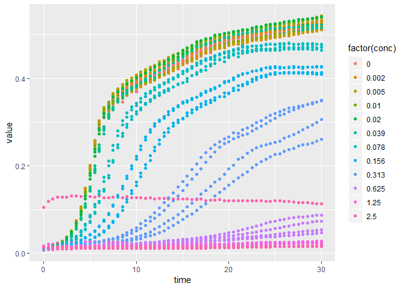

figure

```r
library(ggplot2)
ggplot(antibiotic,aes(x=time,y=value,color=factor(conc)))+geom_point()
```

Wow, these look like some pretty well-behaved data! The replicates at the same antibiotic concentration are pretty similar to each other, while bacteria grown at increasing antibiotic concentrations show decreasing growth rates. Trying to build a model to include time and antibiotic concentration is a bit above our paygrade right now. Let’s just focus on a single concentration; why not start at 0. The package `dplyr` has some nice tools for quickly filtering data to particular subsets. Don’t forget to install it first!

```r
library(dplyr)
```

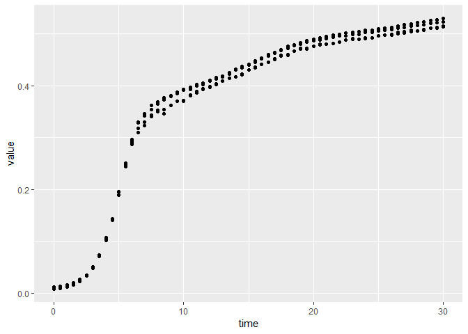

figure

```r
antibiotic_0 <- filter(antibiotic, conc == 0)
ggplot(antibiotic_0,aes(x=time,y=value))+geom_point()
```

## Comparing with a theoretical model

Okay, so how do we model this? If you’re currently taking BIS 23a or a similar course, you may have learned about this in lecture. For a refresher, this [Khan Academy page](https://www.khanacademy.org/science/biology/ecology/population-growth-and-regulation/a/exponential-logistic-growth) has a walkthrough about modeling population growth.

The simplest model is often the best. If it fits the data well, then you can have clear interpretations and predictions. Let’s start with basic, exponential growth and see how it looks. Fundamentally, the exponential model is based on the assumption that a population’s growth rate is proportional the current population size. In other words, even though each individual reproduces at a similar rate, on average, the actual rate of new offspring will go up as the population increases. For humans, there are many factors that make the global population growth different from exponential. [Our World in Data](https://ourworldindata.org/world-population-growth) has a nice deep dive into human population growth trends.

But for bacteria, particularly at small population sizes, the exponential model might fit well. In mathematical terms, our assumption of proportional growth rate can be translated into an equation as $\frac{dN}{dt} = rN$. Here *N* is the population size, *t* is the time variable, and *r* is a parameter to represent the growth rate. You can think of *r* as a parameter that represents net growth, incorporating both births and deaths. If a population is decreasing, it’s totally possible that *r* could be negative, when births are occurring less often than deaths. To put the equation into words, the change in population as a particular moment equals the growth rate *r* times the population size *N*.

But does it fit our data well? This next step will get you used to the typical way that we visualize models in R.

## Visualizing the exponential model

To plot the function, we can generate model output by taking a vector of time points, and applying the function to each one. It feels confusing at first, but it’s surprisingly simple to do.

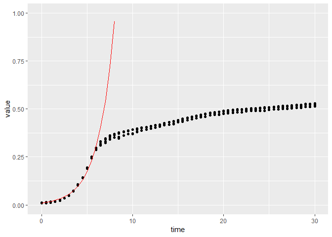

figure

```r
r <- 0.57
N0 <- 0.01
antibiotic_0 <- mutate(antibiotic_0, model_output = exp(r*time)*N0)
p <- ggplot(antibiotic_0,aes(x=time,y=value))+geom_point()
p <- p + geom_line(aes(y=model_output), color = "red")
p <- p + ylim(c(0,1))
p
```

But… this model is definitely not fitting the data at later times.

#### Exploration – model parameters

> *We got the data to fit fairly well at early time steps, but then it was way off for later times. Can you find *r* and *N*(0) to fit the data better> Explore a little bit by changing the value of the varaibles *r* and *N*0 in the code above, and re-running the plot. I suspect you won’t ever find a great fit. Why not?

Okay, our basic exponential model was not up to the task of explaining these data. But we do know of another model (also reviewed on the [Khan](https://www.khanacademy.org/science/biology/ecology/population-growth-and-regulation/a/exponential-logistic-growth) page) to try. This is called the logistic model. Instead of assuming that the population will *always* grow at a rate proportional to population size, we now consider that at some point the population growth may slow down. There may be constraints on resources like food, water, or space that prevent neverending population growth. A first take on this might start with our similar equation $\frac{dN}{dt} = rN$, but add a second factor that will take $\frac{dN}{dt}$ towards 0 as *N* reaches some maximum population size *K*. Note: in ecology this parameter *K* is often called the *carrying capacity*. Let’s try out this updated equation: $\frac{dN}{dt} = rN(1-\frac{N}{K})$. Now when *N* is much smaller than *K*, we basically have the familiar exponential growth. But as *N* gets close in value to *K*, then the term $(1-\frac{N}{K})$ gets close to 0, and population growth will slow to a halt.

Page built on: 2018-09-11 at 15:49:03